# PANORAMA ECONÔMICO E ANÁLISE SETORIAL DE MERCADOS

João Ricardo F. de Lima

03 de Março de 2023.

# O Mercado de Trabalho

Como visto, a soma de bens e serviços finais produzidos por um país em um determinado período depende, basicamente, da disponibilidade de fatores de produção e da forma como esses fatores são combinados. Assim, é preciso entender sobre a dinâmica desses fatores, ou seja, sobre como a oferta e a demanda por eles evolui ao longo do tempo.

Com esse objetivo, é importante definir alguns conceitos. O total de pessoas de um país divide-se em dois grandes grupos: a população inativa e a ativa. O primeiro grupo é composto, basicamente, por crianças e idosos, enquanto o segundo pelo grupo de pessoas que **estariam aptas a exercer algum tipo de trabalho**.

A **população em idade ativa (PIA)**, por sua vez, se divide em **população economicamente ativa (PEA)** e **população não economicamente ativa (PNEA)**. No primeiro grupo estão as **pessoas ocupadas (PO)** e as **pessoas desocupadas, mas em busca de ocupação (PD)**, enquanto no segundo estão as **pessoas desocupadas, que não estão buscando ocupação**. Em resumo:

$$População = PIA + Inativos
\tag{1}$$
$$PIA = PEA + PNEA
\tag{2}$$

$$PEA = PO + PD
\tag{3}$$

$$PD = PEA - PO
\tag{4}$$

$$\frac{PD}{PEA} = 1 - \frac{PO}{PEA}
\tag{5}$$

$$Participação = \frac{PEA}{PIA}
\tag{6}$$

O que conhecemos, nesse contexto, como **taxa de desemprego** nada mais é do que a resultante final de uma complexa interação entre oferta e demanda de trabalho. O grau de ociosidade nesse mercado, por fim, vai definir a qual taxa os salários irão crescer, que pode ser maior, menor ou igual ao crescimento da produtividade da economia.

A análise do mercado de trabalho pode ser feita com base nos dados do CAGED (Cadastro Geral de Empregados e Desempregados) ou com os dados **Pesquisa Nacional por Amostra de Domicílios Contínua** organizada e divulgada pelo IBGE. A PNAD Contínua, de abrangência nacional, veio substituir a Pesquisa Mensal de Emprego (PME), que englobava apenas as seis maiores regiões metropolitanas do país.

#### Evolução Dados sobre Mercado de Trabalho

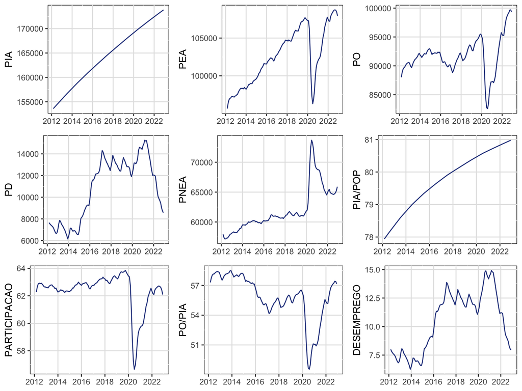

Figura 1: Evolução Dados sobre Mercado de Trabalho

```r
#Analise do Mercado de Trabalho
#https://sidra.ibge.gov.br/home/pnadcm
library(sidrar)
library(GetTDData)
library(readr)
library(xts)
library(forecast)
library(scales)
library(ggplot2)
library(mFilter)
library(grid)
library(png)
library(rbcb)
library(Quandl)
#library(tidyverse)
library(plotly)
library(BMR)
#datamt0 <- get_sidra(api='/t/6022/n1/all/v/606/p/all') #Populacao
#datamt1 <- get_sidra(api='t/6318/n1/all/v/1641/p/all/c629/32385') #PIA+PD+PEA
#datamt2 <- get_sidra(api='t/6318/n1/all/v/1641/p/all/c629/32386')#PIA
#datamt3 <- get_sidra(api='t/6318/n1/all/v/1641/p/all/c629/32387')
#datamt4 <- get_sidra(api='t/6318/n1/all/v/1641/p/all/c629/32446')
#datamt5 <-get_sidra(api='/t/6320/n1/all/v/4090/p/all/c11913/31722,31723,31724,31727,31731,96165,96170,96171') #PIA
#http://api.sidra.ibge.gov.br/values/t/6323/n1/all/v/4090/p/first%2077/c693/all

#write.csv2(datamt0, file='arquivo12a.csv')

dataa <- ts(read.csv2('arquivo12a.csv', header=T,
                     sep=';'),
           start=c(2012,03), freq=12)

data <- ts(read.csv2('arquivo12.csv', header=T,
                     sep=';', dec=',', skip=4)[,-1],
           start=c(2012,03), freq=12)

data <- na.omit(data)

data <- cbind.data.frame(dataa[,6], data)

### Calcular Series e Taxas
pnea <- data[,2] - data[,3] # Populacao nao economicamente ativa
pia.pop <- data[,2]/data[,1]*100 # PIA/Populacao PIA= Pop. Idade Ativa
participacao <- data[,3]/data[,2]*100 # PEA/PIA PEA=PO+PD
ocupacao.pia <- data[,4]/data[,2]*100 # PO/PIA PO=POp Ocupada
desemprego <- data[,5]/data[,3]*100 #PD/PEA PD=Pop Desocupada

macro <- cbind(data[,1:5], pnea, pia.pop, participacao, ocupacao.pia,
               desemprego)
colnames(macro) <- c('Populacao', 'PIA', 'PEA', 'PO', 'PD', 'PNEA',
                     'PIA/POP', 'PARTICIPACAO', 'PO/PIA', 'DESEMPREGO')

macro <- ts(macro, start=c(2012,03), freq=12)
### Variacao internanual
interanual <- (macro/stats::lag(macro,-12)-1)*100
colnames(interanual) <- colnames(macro)

### Variacao internanual
interdecanual <- (macro/stats::lag(macro,-120)-1)*100
colnames(interanual) <- colnames(macro)

interanual1<-interanual[,-1]
#plot1 <- window(interanual1, end=c(2016,6))

dates <- seq(as.Date('2012-03-01'),
             as.Date('2022-12-01'), by='1 month')
macro1 <- macro[,-1]
gtsplot(macro1, dates=dates)
```

#### Mercado de Trabalho, Variação Interanual

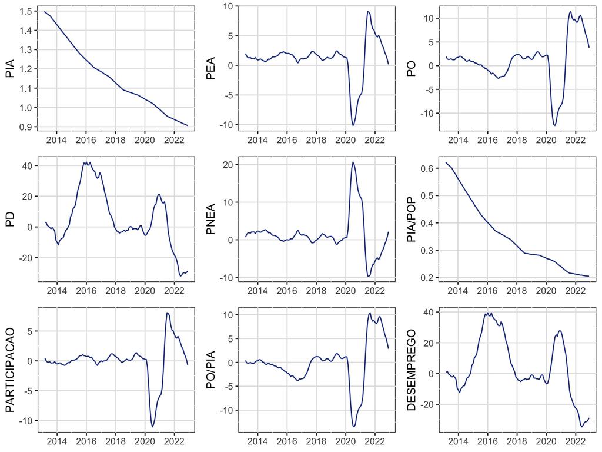

Figura 2: Variações Interanuais das métricas principais da PNAD Contínua

```r
dates <- seq(as.Date('2013-03-01'),
             as.Date('2022-12-01'), by='1 month')
gtsplot(interanual1, dates=dates)
```

#### Métricas da PNAD Contínua

```r
#Tabela

c1 <- tail(macro, n=1)
c2 <- macro[nrow(macro)-12,]
c3 <- tail(interanual, n=1)
c4 <- macro[nrow(macro)-120,]
table <- t(rbind(c1,c2,c3,c4))
colnames(table) <- c('Dez/22', 'Dez/21', 'Variação', 'Dez/12')

library(DT)

datatable(round(table,2),
          options = list(pageLength = 11,
                         dom = 't',
                         columnDefs =
                           list(list(className = 'dt-center', targets = "_all"))))
```

|  | Dez/22 | Dez/21 | Variação | Dez/12 |
| --- | --- | --- | --- | --- |
| Populacao | 214680 | 213188 | 0.7 | 198360 |
| PIA | 173844 | 172283 | 0.91 | 155330 |
| PEA | 107942 | 107758 | 0.17 | 97322 |
| PO | 99370 | 95747 | 3.78 | 90593 |
| PD | 8572 | 12011 | -28.63 | 6730 |
| PNEA | 65902 | 64525 | 2.13 | 58008 |
| PIA/POP | 80.98 | 80.81 | 0.2 | 78.31 |
| PARTICIPACAO | 62.09 | 62.55 | -0.73 | 62.65 |
| PO/PIA | 57.16 | 55.58 | 2.85 | 58.32 |
| DESEMPREGO | 7.94 | 11.15 | -28.75 | 6.92 |

#### Desagregação da População Ocupada

De forma a compreender o comportamento da demanda por trabalho, é importante saber desagregar os dados da PNAD Contínua.

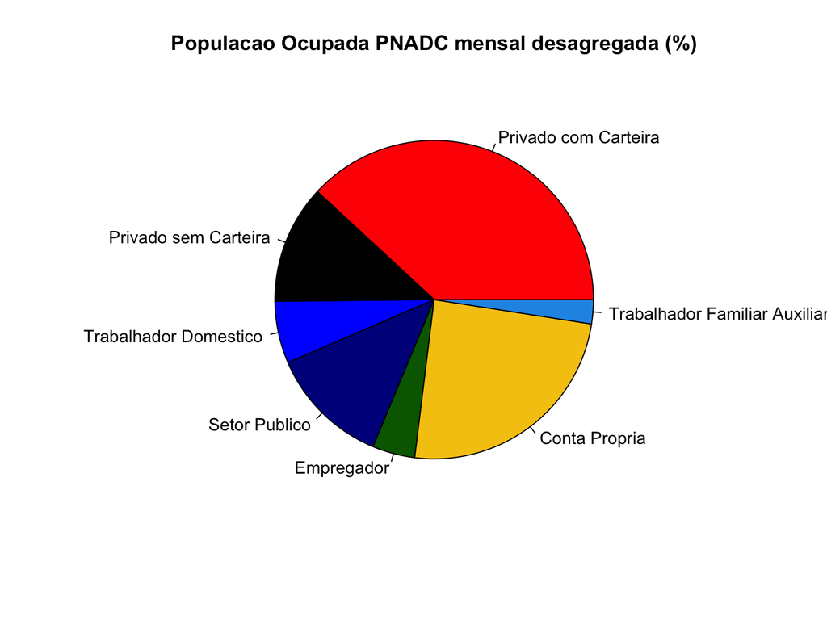

Figura 3: Desagregação da População Ocupada

```r
#datab <- get_sidra(api='t/6320/n1/all/v/4090/p/all/c11913/31722,31723,31724,31727,31731,96170,96171')

datab <- ts(read.csv2('arquivo12b.csv', header=T,
                     sep=';', dec=',', skip=4)[,-1],
           start=c(2012,03), freq=12)

pesos.po <- na.omit(datab)

pesos.po1 <- (pesos.po/data[,4])*100

colnames(pesos.po1) <- c("Privado com Carteira",
                         "Privado sem Carteira",
                         "Trabalhador Domestico",
                         "Setor Publico",
                         "Empregador","Conta Propria",
                         "Trabalhador Familiar Auxiliar")

### Gerar Grafico
pie(colMeans(pesos.po1), col=c('red','black','blue','darkblue',
                               'darkgreen', '367', '556'),
    main='Populacao Ocupada PNADC mensal desagregada (%)')
```

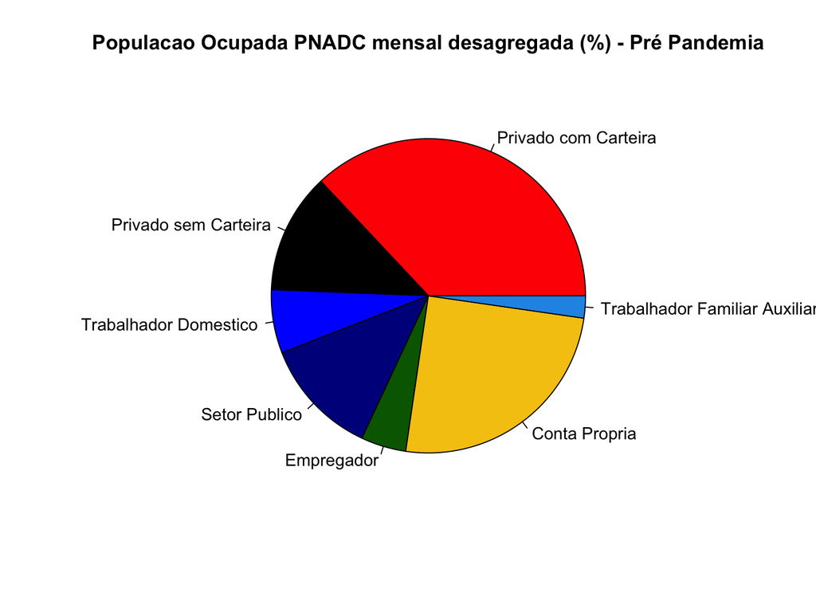

Figura 4: Desagregação da População Ocupada

```r
pesos.po2 <- window(pesos.po1, start=c(2017,3), end=c(2020,3))
### Gerar Grafico
pie(colMeans(pesos.po2), col=c('red','black','blue','darkblue',
                               'darkgreen', '367', '556'),
    main='Populacao Ocupada PNADC mensal desagregada (%) - Pré Pandemia')
```

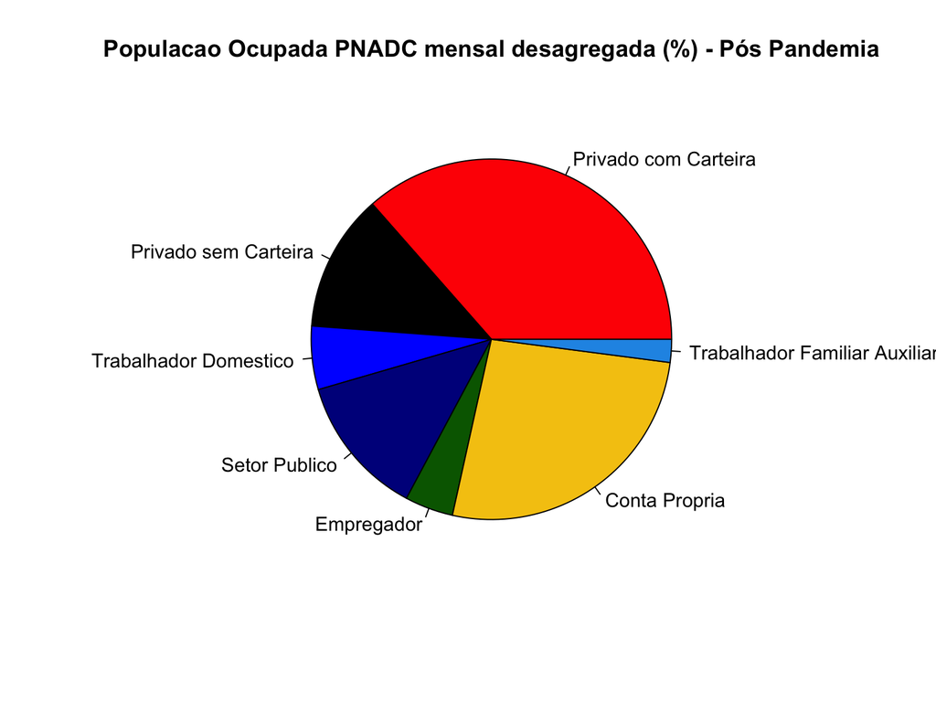

Figura 5: Desagregação da População Ocupada

```r
pesos.po3 <- window(pesos.po1, start=c(2020,3))
### Gerar Grafico
pie(colMeans(pesos.po3), col=c('red','black','blue','darkblue',
                               'darkgreen', '367', '556'),
    main='Populacao Ocupada PNADC mensal desagregada (%) - Pós Pandemia')
```

```r
pie1 <- colMeans(pesos.po1)
pie2 <- colMeans(pesos.po2)
pie3 <- colMeans(pesos.po3)

table <- cbind(pie1, pie2, pie3)

colnames(table) <- c("Média Série", "Média pós 2017", "Média pós 2020")

datatable(round(table,2),
          options = list(pageLength = 7,
                         dom = 't',
                         columnDefs =
                           list(list(className = 'dt-center', targets = "_all"))))
```

|  | Média Série | Média pós 2017 | Média pós 2020 |
| --- | --- | --- | --- |
| Privado com Carteira | 38.12 | 37 | 36.49 |
| Privado sem Carteira | 12.06 | 12.39 | 12.34 |
| Trabalhador Domestico | 6.29 | 6.52 | 5.68 |
| Setor Publico | 12.27 | 12.14 | 12.69 |
| Empregador | 4.31 | 4.64 | 4.34 |
| Conta Propria | 24.51 | 25.03 | 26.41 |
| Trabalhador Familiar Auxiliar | 2.45 | 2.28 | 2.06 |

#### Variação Interanual da Taxa de Desemprego PNADC

Uma outra métrica interessante para análise da situação do desemprego pode ser obtida confrontando o dado em t contra o mesmo dado em t-12. Obtém-se, assim, o chamado de variação interanual do desemprego.

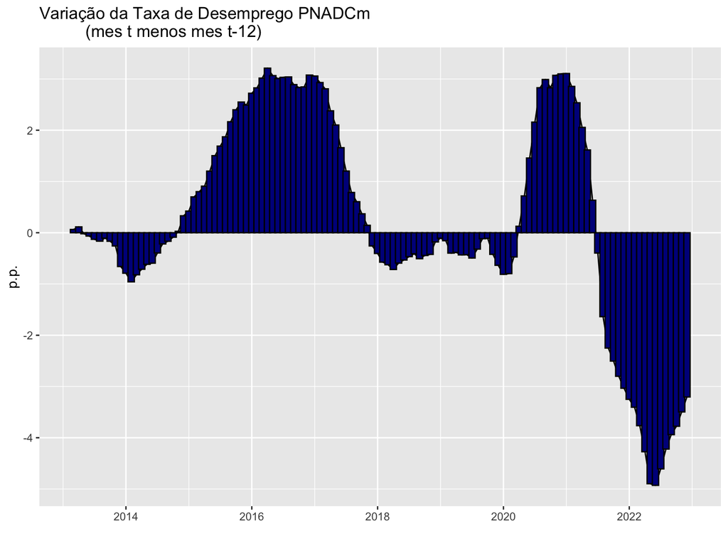

Figura 6: Variação Interanual da Taxa de Desemprego PNADC

```r
#interanual <- (macro/lag(macro,-12)-1)*100
#Variacao Interanual do Desemprego
composicao <- macro[,10] - lag(macro[,10],-12)
autoplot(composicao) +
  geom_bar(colour="black",
           fill="darkblue", width=.1, stat="identity") +
  xlab('') + ylab('p.p.') +
  ggtitle('Variação da Taxa de Desemprego PNADCm
          (mes t menos mes t-12)')
```

#### Dessazonalização da taxa de desemprego

Um dos grandes problemas da PNAD Contínua é que ela é uma série curta. Isso significa que não é possível usar técnicas econométricas mais sofisticadas. Contudo, é possível contornar o problema estimando o modelo dinâmico abaixo:

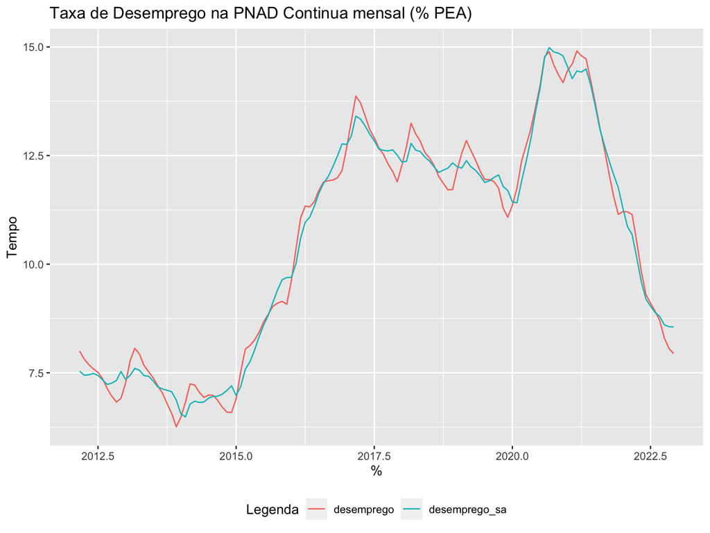

Figura 7: Taxa de Desemprego na PNAD Contínua mensal (% PEA)

```r
library(dynlm)
#Dessazonalizacao da taxa de desemprego
dynlm <- dynlm(macro[,10]~season(macro[,10]))
desemprego_sa <- residuals(dynlm) + mean(fitted(dynlm))
pnadc.desemprego <- cbind(desemprego, desemprego_sa)

p <- autoplot(pnadc.desemprego, facets=F,
              main='Taxa de Desemprego na PNAD Continua mensal (% PEA)', xlab = "%", ylab = "Tempo")
p + scale_colour_hue("Legenda") + scale_size_manual(values = 2)+
  theme(legend.position="bottom")
```